# Analysis of U.S. Homicide Reports (1980-2014)

## Introduction

According to Statista, there were a total of 17,284 reported murder and non-negligent manslaughter cases in the U.S in 2017. To improve the response to homicides, analysis of key factors relating to these crimes is required. This tutorial is using dataset of U.S. Homicide Reports from 1980-2014 and aims to provide analysis on key factors like age, sex, race and state. This tutorial is also using dataset of U.S. Census demographic data of 2015 which will help in providing relation between homicides and population and poverty. Although homicides have reduced drastically over the years, there is still a lot of path to cover.

## Contents

1. Data collection and cleaning
2. Data analysis and visualisation
3. Linear Regression and Hypothesis testing
4. Conclusion
5. References

## Required Tools

You will need the following libraries for this project:

1. folium
2. matplotlib.pyplot
3. scikit-learn
4. pandas

We highly recommend using Jupyter Notebook with built in Python 3 support or you can refer to the following resources for more information about pandas/installation and python 3.6 in general:

1. https://pandas.pydata.org/pandas-docs/stable/install.html
2. https://docs.python.org/3/

```python
#Import needed libraries
!pip install folium
import folium
import matplotlib.pyplot as plt
from sklearn.linear_model import LinearRegression
import pandas as pd
import os
from statsmodels.formula.api import ols
import statsmodels.api as sm
```

```
You are using pip version 9.0.3, however version 18.1 is available.
```

## 1. Data collection and cleaning : Scraping data and tidying

### 1.1. Data collection

The dataset has been downloaded from https://www.kaggle.com/murderaccountability/homicide-reports/downloads/database.csv/1. Another dataset has been downloaded from https://www.kaggle.com/muonneutrino/us-census-demographic-data/downloads/acs2015_census_tract_data.csv/1. Then both downloaded CSV file database.csv and acs2015_census_tract_data.csv is read using pandas library function read_csv into a dataframe. You can learn more about pandas and its internal functions here: https://pandas.pydata.org/pandas-docs/stable/

```python
# Load csv file
data = pd.read_csv("database.csv", dtype=object)
# Display the first 5 rows of the table
data.head()
```

|  | Record ID | Agency Code | Agency Name | Agency Type | City | State | Year | Month | Incident | Crime Type | ... | Victim Ethnicity | Perpetrator Sex | Perpetrator Age | Perpetrator Race | Perpetrator Ethnicity | Relationship | Weapon | Victim Count | Perpetrator Count | Record Source |
| --- | --- | --- | --- | --- | --- | --- | --- | --- | --- | --- | --- | --- | --- | --- | --- | --- | --- | --- | --- | --- | --- |
| 0 | 000001 | AK00101 | Anchorage | Municipal Police | Anchorage | Alaska | 1980 | January | 1 | Murder or Manslaughter | ... | Unknown | Male | 15 | Native American/Alaska Native | Unknown | Acquaintance | Blunt Object | 0 | 0 | FBI |
| 1 | 000002 | AK00101 | Anchorage | Municipal Police | Anchorage | Alaska | 1980 | March | 1 | Murder or Manslaughter | ... | Unknown | Male | 42 | White | Unknown | Acquaintance | Strangulation | 0 | 0 | FBI |
| 2 | 000003 | AK00101 | Anchorage | Municipal Police | Anchorage | Alaska | 1980 | March | 2 | Murder or Manslaughter | ... | Unknown | Unknown | 0 | Unknown | Unknown | Unknown | Unknown | 0 | 0 | FBI |
| 3 | 000004 | AK00101 | Anchorage | Municipal Police | Anchorage | Alaska | 1980 | April | 1 | Murder or Manslaughter | ... | Unknown | Male | 42 | White | Unknown | Acquaintance | Strangulation | 0 | 0 | FBI |
| 4 | 000005 | AK00101 | Anchorage | Municipal Police | Anchorage | Alaska | 1980 | April | 2 | Murder or Manslaughter | ... | Unknown | Unknown | 0 | Unknown | Unknown | Unknown | Unknown | 0 | 1 | FBI |

5 rows × 24 columns

```python
# Load csv file
datac = pd.read_csv("acs2015_census_tract_data.csv", dtype=object)
# Display the first 5 rows of the table
datac.head()
```

|  | CensusTract | State | County | TotalPop | Men | Women | Hispanic | White | Black | Native | ... | Walk | OtherTransp | WorkAtHome | MeanCommute | Employed | PrivateWork | PublicWork | SelfEmployed | FamilyWork | Unemployment |
| --- | --- | --- | --- | --- | --- | --- | --- | --- | --- | --- | --- | --- | --- | --- | --- | --- | --- | --- | --- | --- | --- |
| 0 | 1001020100 | Alabama | Autauga | 1948 | 940 | 1008 | 0.9 | 87.4 | 7.7 | 0.3 | ... | 0.5 | 2.3 | 2.1 | 25.0 | 943 | 77.1 | 18.3 | 4.6 | 0.0 | 5.4 |
| 1 | 1001020200 | Alabama | Autauga | 2156 | 1059 | 1097 | 0.8 | 40.4 | 53.3 | 0.0 | ... | 0.0 | 0.7 | 0.0 | 23.4 | 753 | 77.0 | 16.9 | 6.1 | 0.0 | 13.3 |
| 2 | 1001020300 | Alabama | Autauga | 2968 | 1364 | 1604 | 0.0 | 74.5 | 18.6 | 0.5 | ... | 0.0 | 0.0 | 2.5 | 19.6 | 1373 | 64.1 | 23.6 | 12.3 | 0.0 | 6.2 |
| 3 | 1001020400 | Alabama | Autauga | 4423 | 2172 | 2251 | 10.5 | 82.8 | 3.7 | 1.6 | ... | 0.0 | 2.6 | 1.6 | 25.3 | 1782 | 75.7 | 21.2 | 3.1 | 0.0 | 10.8 |
| 4 | 1001020500 | Alabama | Autauga | 10763 | 4922 | 5841 | 0.7 | 68.5 | 24.8 | 0.0 | ... | 0.0 | 0.6 | 0.9 | 24.8 | 5037 | 67.1 | 27.6 | 5.3 | 0.0 | 4.2 |

5 rows × 37 columns

### 1.2. Data cleaning / tidying

There are various columns in data and datac table which are not required for our analysis so we will drop them. Also some analysis will require information which only Solved Crimes have like Age, Race, Sex so to tidy the dataset, we will deal with it in data preparation section of each part.

```python
# Drop all unnecessary columns
data = data.drop('Agency Code', 1)
data = data.drop('Agency Name', 1)
data = data.drop('Agency Type', 1)
data = data.drop('Victim Ethnicity', 1) # Mostly unknown
data = data.drop('Perpetrator Ethnicity', 1) # Mostly unknown
data = data.drop('Victim Count', 1)
data = data.drop('Perpetrator Count', 1)
data = data.drop('Record Source', 1)

# Convert Year type to int
data['Year'] = data['Year'].astype(int)
data.head()
```

|  | Record ID | City | State | Year | Month | Incident | Crime Type | Crime Solved | Victim Sex | Victim Age | Victim Race | Perpetrator Sex | Perpetrator Age | Perpetrator Race | Relationship | Weapon |
| --- | --- | --- | --- | --- | --- | --- | --- | --- | --- | --- | --- | --- | --- | --- | --- | --- |
| 0 | 000001 | Anchorage | Alaska | 1980 | January | 1 | Murder or Manslaughter | Yes | Male | 14 | Native American/Alaska Native | Male | 15 | Native American/Alaska Native | Acquaintance | Blunt Object |
| 1 | 000002 | Anchorage | Alaska | 1980 | March | 1 | Murder or Manslaughter | Yes | Male | 43 | White | Male | 42 | White | Acquaintance | Strangulation |
| 2 | 000003 | Anchorage | Alaska | 1980 | March | 2 | Murder or Manslaughter | No | Female | 30 | Native American/Alaska Native | Unknown | 0 | Unknown | Unknown | Unknown |
| 3 | 000004 | Anchorage | Alaska | 1980 | April | 1 | Murder or Manslaughter | Yes | Male | 43 | White | Male | 42 | White | Acquaintance | Strangulation |
| 4 | 000005 | Anchorage | Alaska | 1980 | April | 2 | Murder or Manslaughter | No | Female | 30 | Native American/Alaska Native | Unknown | 0 | Unknown | Unknown | Unknown |

Below part contains data tidying for 'acs2015_census_tract_data.csv' database

```python
# Create DataFrame with required columns
datac = pd.DataFrame(datac, columns = ['State', 'TotalPop', 'Income', 'IncomePerCap', 'Poverty', 'Unemployment'])
datac['TotalPop'] = datac['TotalPop'].astype(int)/100000 # Population in 100,000
datac['Poverty'] = datac['TotalPop']*(datac['Poverty'].astype(float)/100) # Poverty in 100,000
datac.head()
```

|  | State | TotalPop | Income | IncomePerCap | Poverty | Unemployment |
| --- | --- | --- | --- | --- | --- | --- |
| 0 | Alabama | 0.01948 | 61838.0 | 25713.0 | 0.001578 | 5.4 |
| 1 | Alabama | 0.02156 | 32303.0 | 18021.0 | 0.005498 | 13.3 |
| 2 | Alabama | 0.02968 | 44922.0 | 20689.0 | 0.003769 | 6.2 |
| 3 | Alabama | 0.04423 | 54329.0 | 24125.0 | 0.000929 | 10.8 |
| 4 | Alabama | 0.10763 | 51965.0 | 27526.0 | 0.012270 | 4.2 |

## 2. Data visualisation and analysis

This part of tutorial deals with data analysis and visualization using pie charts, plots and maps.

### 2.1. Homicide cases solved v/s unsolved

In this part of tutorial, we will analyse the percentage of crimes solved across 1980 - 2014. This will help us understand what percentage of cases remain unsolved as a mystery.

#### 2.1.1. Data preparation

Firstly, we will store Crime Solved in new DataFrame and then count the number of Crimes Solved by making use of pandas library functions - groupby and count.

You can know more about Pandas groupby: https://pandas.pydata.org/pandas-docs/stable/generated/pandas.DataFrame.groupby.html and Pandas count: https://pandas.pydata.org/pandas-docs/stable/generated/pandas.DataFrame.count.html

```python
solved = pd.DataFrame(data, columns = ['Crime Solved'])
resolution = solved.groupby(data['Crime Solved'])['Crime Solved'].count()
```

#### 2.1.2. Data visualization and analysis

Now we plot the data on a pie chart to show percentage of homicide cases solved over the years.

```
Text(0,0.5,'')
```

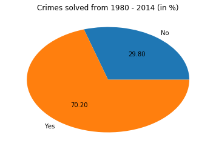

```python
ax = resolution.plot(kind = 'pie',
title = 'Crimes solved from 1980 - 2014 (in %)',
startangle = 0,
autopct='%.2f')
ax.set_ylabel('')
```

The above pie chart shows that still 29.8 % of homicide cases are unsolved in the U.S.

### 2.2. Homicide cases by Race

In this part of tutorial, we will analyse the race division among perpetrators and victims across 1980 - 2014 and try to find out the the race having highest victim and perpetrator and also answer to who killed whom in terms of race.

#### 2.2.1. Data preparation

Firstly, we will store Race in new DataFrame and then count the race which victims and perpetrator belonged to by making use of pandas library functions - groupby and count. In the below step we will be doing data preparation for 3 plots - Pie chart of Victim race, Perpetrator race and a Bar plot showing relation between Victim and Perpetrator of each race. In these plots, we will have to eliminate cases where any of the race is Unknown to provide better analysis.

```python
race = pd.DataFrame(data, columns = ['Victim Race', 'Perpetrator Race'])
race = race[race['Victim Race'] != 'Unknown'] # Remove Unknown for Victim race
race = race[race['Perpetrator Race'] != 'Unknown'] # Remove Unknown for Perpetrator race
racevic = race.groupby(['Victim Race'])['Victim Race'].count() # DataFrame with Count for Victim race
raceperp = race.groupby(['Perpetrator Race'])['Perpetrator Race'].count() # DataFrame with Count for Perpetrator race
racerel = race.groupby(['Victim Race', 'Perpetrator Race'])['Victim Race'].count() # DataFrame for relation
```

#### 2.2.2. Data visualization and analysis

The following section shows 3 plots - Pie chart of Victim race, Perpetrator race and a Bar plot showing relation between Victim and Perpetrator of each race.

Now we plot the data on a pie chart to show race division of Victims.

```
Text(0,0.5,'')
```

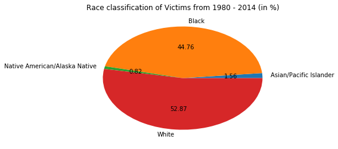

```python
ax = racevic.plot(kind = 'pie',
title = 'Race classification of Victims from 1980 - 2014 (in %)',
startangle = 0,
autopct='%.2f')
ax.set_ylabel('')
```

Majority of Victims are White with second highest being Black victims.

Now we plot the data on a pie chart to show race division of Perpetrators.

```
Text(0,0.5,'')
```

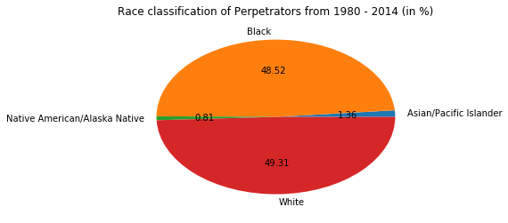

```python
ax = raceperp.plot(kind = 'pie',
title = 'Race classification of Perpetrators from 1980 - 2014 (in %)',
startangle = 0,
autopct='%.2f')
ax.set_ylabel('')
```

Now we plot the data on a Bar plot to show number of homicides where Victim and Perpetrator belong to a particular race.

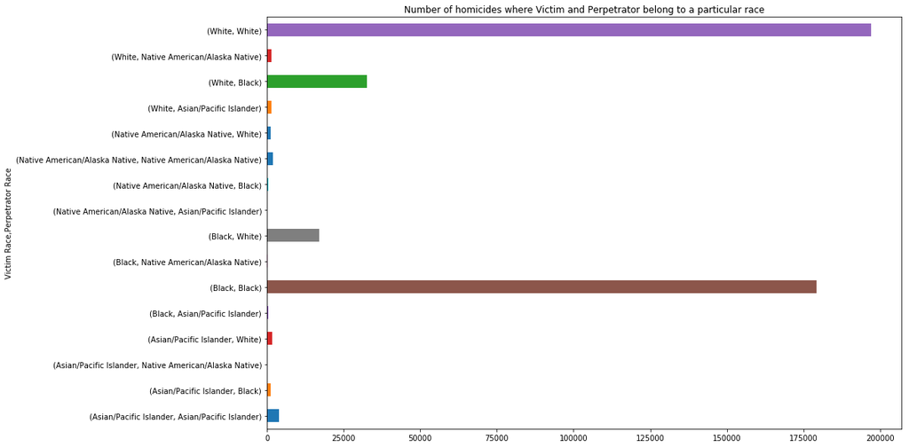

```python
ax = racerel.plot(kind='barh', fontsize=10,  width=0.5,  figsize=(15, 10), title='Number of homicides where Victim and Perpetrator belong to a particular race')
```

It can be inferred from the above plot that majority of homicides in U.S. have a White Victim and White Perpetrator with Black Victim and Black Perpetrator coming second. This puts rest to the popular misconception that Inter-racial homicides are very common. This data does not include cases where either Victim or Perpetrator has race as Unknown.

### 2.3. Homicide cases by Sex

In this part of tutorial, we will analyse the sex classification of perpetrators and victims across 1980 - 2014 and try to find out the most popular comination among Man killing Man, Man killing Woman, Woman killing Man and Woman killing Woman.

#### 2.3.1. Data preparation

Firstly, we will store Sex in new DataFrame and then count the Sex which victims and perpetrator belonged to by making use of pandas library functions - groupby and count. In the below step we will be doing data preparation for 3 plots - Pie chart of Victim Sex, Perpetrator Sex and a Bar plot showing relation between Victim and Perpetrator of each Sex. In these plots, we will have to eliminate cases where Sex is Unknown to provide better analysis.

```python
sex = pd.DataFrame(data, columns = ['Victim Sex', 'Perpetrator Sex'])
sex = sex[sex['Victim Sex'] != 'Unknown'] # Remove Unknown for Victim Sex
sex = sex[sex['Perpetrator Sex'] != 'Unknown'] # Remove Unknown for Perpetrator Sex
sexvic = sex.groupby(['Victim Sex'])['Victim Sex'].count() # DataFrame with Count for Victim Sex
sexperp = sex.groupby(['Perpetrator Sex'])['Perpetrator Sex'].count() # DataFrame with Count for Perpetrator Sex
sexrel = sex.groupby(['Victim Sex', 'Perpetrator Sex'])['Victim Sex'].count() # DataFrame for relation
```

#### 2.3.2. Data visualization and analysis

The following section shows 3 plots - Pie chart of Victim Sex, Perpetrator Sex and a Bar plot showing relation between Victim and Perpetrator of each Sex.

Now we plot the data on a pie chart to show Sex division of Victims.

```
Text(0,0.5,'')
```

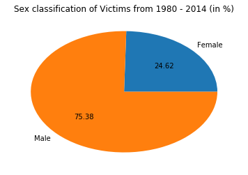

```python
ax = sexvic.plot(kind = 'pie',
title = 'Sex classification of Victims from 1980 - 2014 (in %)',
startangle = 0,
autopct='%.2f')
ax.set_ylabel('')
```

Majority of Victims (75.38%) are Male.

Now we plot the data on a pie chart to show sex division of Perpetrators.

```
Text(0,0.5,'')
```

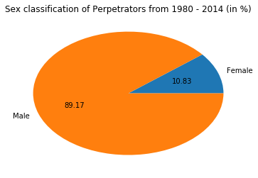

```python
ax = sexperp.plot(kind = 'pie',
title = 'Sex classification of Perpetrators from 1980 - 2014 (in %)',
startangle = 0,
autopct='%.2f')
ax.set_ylabel('')
```

Majority of Perpetrators are also Male and female Perpetrators are very less (10.83%).

Now we plot the data on a Bar plot to show number of homicides where Victim and Perpetrator belong to a particular combination of sex.

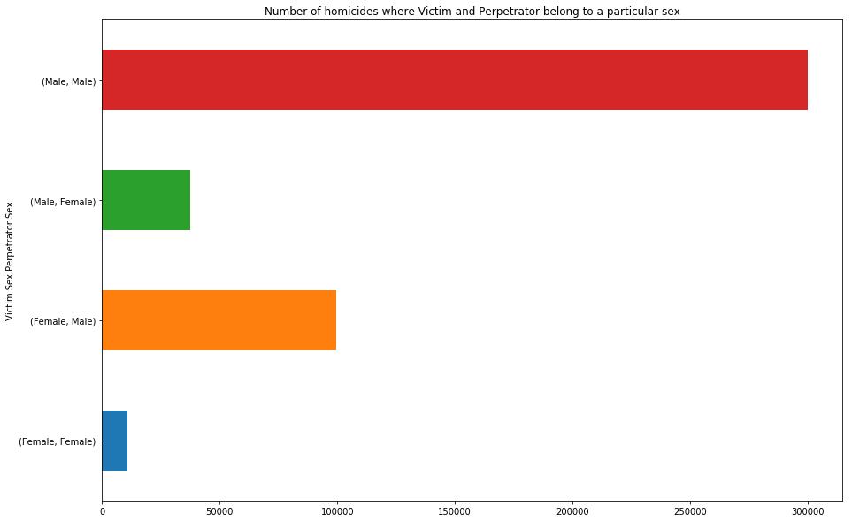

```python
ax = sexrel.plot(kind='barh', fontsize=10,  width=0.5,  figsize=(15, 10), title='Number of homicides where Victim and Perpetrator belong to a particular sex')
```

It can be inferred from the above plot that majority of homicides in U.S. have a Male Victim and Male Perpetrator with Female Victim and Male Perpetrator almost a third of it. This data does not include cases where either Victim or Perpetrator has sex as Unknown.

### 2.4. Homicide cases by Age

In this part of tutorial, we will analyse the number of perpetrators by age and try to find out the age that highest number of perpetrators have, the average age and the trends in perpetrator count across all ages.

#### 2.4.1. Data preparation

```python
age = pd.DataFrame(data, columns = ['Victim Age', 'Perpetrator Age'])
age = age[age['Perpetrator Age'] != '0'] # Remove Perpetrator Age is 0
age = age[age['Perpetrator Age'] != ' '] # Remove Perpetrator Age is ' '
age = age[age['Victim Age'] != '0'] # Remove Victim Age is 0
age = age[age['Victim Age'] != ' '] # Remove Victim Age is ' '
# Convert Perpetrator and Victim Age type to int
age['Perpetrator Age'] = age['Perpetrator Age'].astype(int)
age['Victim Age'] = age['Victim Age'].astype(int)
age = age[age['Victim Age'] < 150] # Remove Victim Age greater than 150
agevic = age.groupby(['Victim Age'])['Victim Age'].count() # DataFrame with Count for Victim Age
ageperp = age.groupby(['Perpetrator Age'])['Perpetrator Age'].count() # DataFrame with Count for Perpetrator Age
agerel = age.groupby(['Victim Age', 'Perpetrator Age'])['Victim Age'].count() # DataFrame for relation
```

#### 2.4.2. Data visualization and analysis

Now we plot the data on a bar plot to show Age division of Victims.

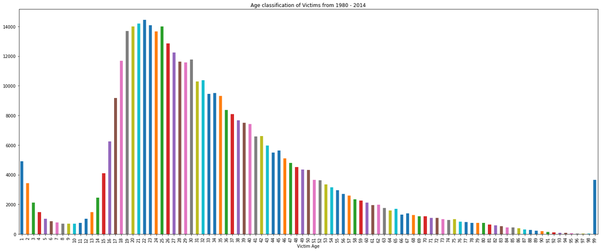

```python
ax = agevic.plot(kind='bar', fontsize=10,  width=0.5,  figsize=(25, 10), title='Age classification of Victims from 1980 - 2014')
```

Highest number of victims belong to the age 22. The Victim count is very high for the age bracket 19-25.

Now we plot the data on a bar plot to show Age division of Perpetrators.

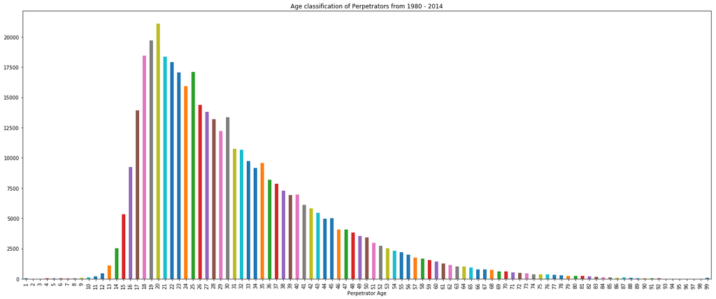

```python
ax = ageperp.plot(kind='bar', fontsize=10,  width=0.5,  figsize=(25, 10), title='Age classification of Perpetrators from 1980 - 2014')
```

Highest number of Perpetrators belong to the age 20. The Perpetrator count is very high for the age bracket 17-30 which is very young age. After that the perpetrator count decreases with age.

#### 2.4.3. Statistics

Below are some of the statistics that can be deduced by the data.

```python
psum = 0
ptot = 0
for x in range(1,100):
    psum += (x*ageperp[x])
    ptot += (ageperp[x])
print("The average age of a perpetrator is " + str(psum/ptot) + " years old.")
```

```
The average age of a perpetrator is 30.8382974823 years old.
```

### 2.5. Homicide cases by State

In this part of tutorial, we will see the number of homicides for each state. We will also find out the top 5 most unsafe states across the U.S and relationship between number of homicides and population, poverty of a state.

#### 2.5.1. Data preparation

Firstly, we will store State in new DataFrame and then count the number of incidents for each state from 1980 - 2014 by making use of pandas library functions - groupby and count. Similarly we will also extract total population of each state of U.S. in 100,000.

```python
state = pd.DataFrame(data, columns = ['State', 'Incident']) # DataFrame with just 2 columns
count_state = state.groupby(data['State']).count() # Count of each State
count_state2 = count_state[['Incident']].reset_index()
states = pd.DataFrame(count_state2, columns = ['State', 'Incident']) # Transfering data to this new DataFrame
states['Perc'] = states['Incident']*100/states['Incident'].sum() # Percentage of Homicide cases
states.head()
```

|  | State | Incident | Perc |
| --- | --- | --- | --- |
| 0 | Alabama | 11376 | 1.781804 |
| 1 | Alaska | 1617 | 0.253268 |
| 2 | Arizona | 12871 | 2.015964 |
| 3 | Arkansas | 6947 | 1.088097 |
| 4 | California | 99783 | 15.628847 |

```python
statepop = pd.DataFrame(datac, columns = ['State', 'TotalPop']) # DataFrame with just 2 columns
statesensus = statepop.groupby(datac['State']).sum() # Total Population of each State in 100,000
statesensus2 = statesensus[['TotalPop']].reset_index()
statesen = pd.DataFrame(statesensus2, columns = ['State', 'TotalPop']) # Transfering data to this new DataFrame
statesen['Perc'] = statesen['TotalPop']*100/statesen['TotalPop'].sum() # Percentage of Population
statesen.head()
```

|  | State | TotalPop | Perc |
| --- | --- | --- | --- |
| 0 | Alabama | 48.30620 | 1.509106 |
| 1 | Alaska | 7.33375 | 0.229109 |
| 2 | Arizona | 66.41928 | 2.074966 |
| 3 | Arkansas | 29.58208 | 0.924157 |
| 4 | California | 384.21464 | 12.003028 |

```python
statepercap = datac.groupby(datac['State'])['Poverty'].sum() # Total Poverty of each State in 100,000
statecap = statepercap.sort_index(axis=0, ascending=True) # Sort in ascending order by State
statecap.head()
```

```
State
Alabama        9.197442
Alaska         0.747254
Arizona       12.228674
Arkansas       5.765263
California    62.726141
Name: Poverty, dtype: float64
```

#### 2.5.2. Data visualization and analysis

Now we plot the data on a bar plot to show pattern of homicide cases per state over the years 1980 - 2014.

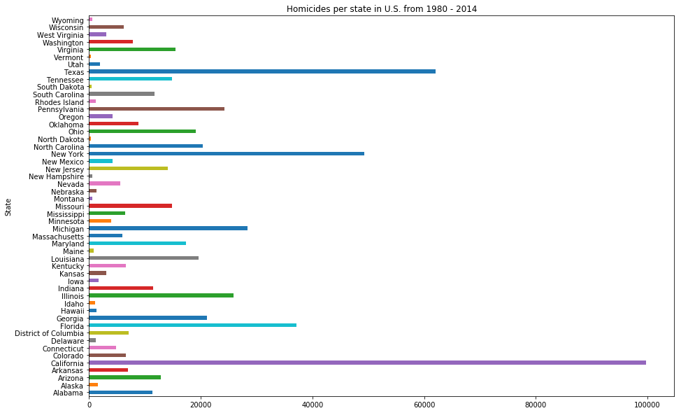

```python
# Plot of homicides v/s state
count_state['Incident'].plot(kind='barh', fontsize=10,  width=0.5,  figsize=(15, 10), title='Homicides per state in U.S. from 1980 - 2014')
```

As we can see from the above plot that California is the most unsafe state, followed by Texas, New York and Florida. Whereas North Dakota is the safest state across the U.S.

Now we plot the total population of each state on a bar plot to show resemblance with plot of homicide cases per state over the years 1980 - 2014.

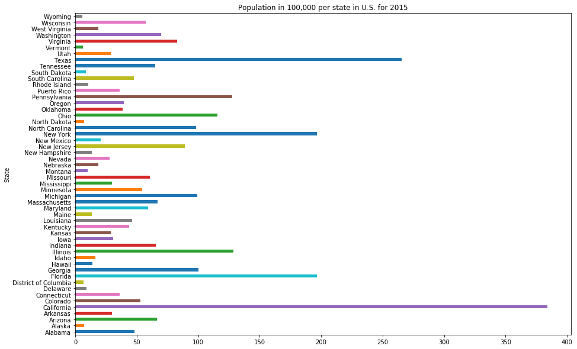

```python
# Plot of population v/s state
statesensus['TotalPop'].plot(kind='barh', fontsize=10,  width=0.5,  figsize=(15, 10), title='Population in 100,000 per state in U.S. for 2015')
```

This plot of Population per state has a strong resemblance to the last plot of Homicides per state. By generalization, we can predict that factors such as population of the state determine its safety. California, Texas, New York, and Florida are among top 4 densely populated states and also the top 4 states with highest number of homicides.

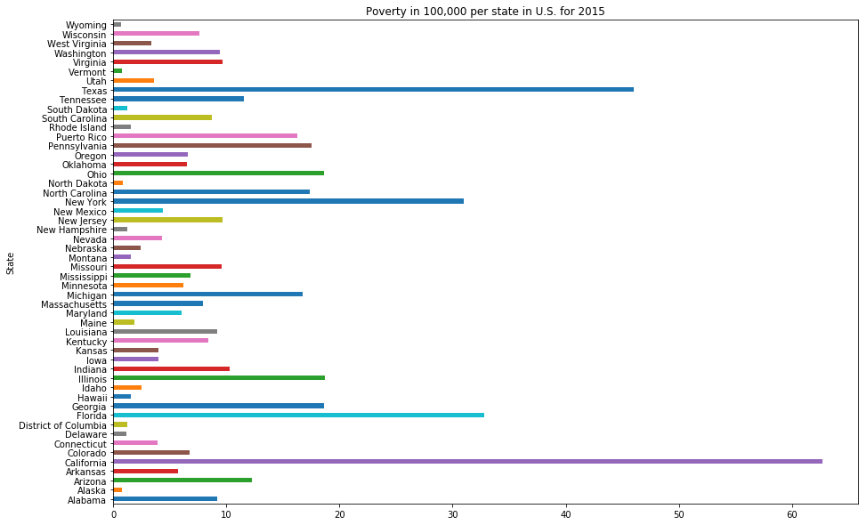

```python
# Plot of Poverty v/s state
statecap.plot(kind='barh', fontsize=10,  width=0.5,  figsize=(15, 10), title='Poverty in 100,000 per state in U.S. for 2015')
```

This plot of Poverty per state has a strong resemblance to the plot of Homicides per state. By generalization, we can predict that factors such as poverty of the state also play a key role to determine its safety. California, Texas, New York, and Florida are among top 4 states with high poverty and also the top 4 states with highest number of homicides. So this relation works.

#### 2.5.3. Data Visualization of State on Choropleth Map

In this part, we will provide 2 Data Visualizations using Choropleth Map. We will be using a python library called Folium to display the maps. Folium allows us to display data on map in different ways using sattelite, terrain, heat and Choropleth maps which are completely customizable. More info about Folium can be found at https://python-visualization.github.io/folium/docs-v0.6.0/. Also https://python-visualization.github.io/folium/quickstart.html has some cool implementations. To import U.S. states with boundaries, we will import a geo-json file called us-states.json which can be downloaded from https://raw.githubusercontent.com/python-visualization/folium/master/examples/data/us-states.json. The 2 maps we will display will be:

1. State wise Homicide percentage
2. State wise population percentage

Both of these maps will help us look at the correlations between population and humicide rate.

Below is the first Map showing State wise Homicide Rate.

```python
# Path for json file
state_geo = os.path.join('us-states.json')
# Initialize map location and zoom level
m = folium.Map(location=[45, -100], zoom_start=3.5)
# Map type will be choropleth to graphically show the homicide percentage state wise
folium.Choropleth(
    geo_data=state_geo,
    name='choropleth',
    data=states,
    columns=['State', 'Perc'],
    key_on='feature.properties.name',
    fill_color='Reds',
    fill_opacity=0.8,
    line_opacity=0.6,
    legend_name='Homicide Rate (%)'
).add_to(m)

folium.LayerControl().add_to(m)
m
```

[interactive chart not shown]

It can be seen in the above map that California, Texas, New York and Florida are darker than the other states showing high Homicide rates.

Below is the second Map showing State wise Population Percentage.

```python
# Initialize map location and zoom level
m = folium.Map(location=[45, -100], zoom_start=3.5)
# Map type will be choropleth to graphically show the Population percentage state wise
folium.Choropleth(
    geo_data=state_geo,
    name='choropleth',
    data=statesen,
    columns=['State', 'Perc'],
    key_on='feature.properties.name',
    fill_color='Reds',
    fill_opacity=0.8,
    line_opacity=0.6,
    legend_name='Population Percentage (%)'
).add_to(m)

folium.LayerControl().add_to(m)
m
```

[interactive chart not shown]

Similar to the last map, California, Texas, New York and Florida are darker than the other states showing high Population rates. The two maps very closely resemble each other. The only exception that can be seen is the state of Virginia. In the first map, Virginia has low homicide rate despite having medium-high population rate as shown in this above map.

### 2.6. Homicide cases by Year

In this part of tutorial, we will analyse the number of homicides per year from 1980 - 2014. We find out about highest homicide count across the years, the average number of homicides and the trends across the years.

#### 2.6.1. Data preparation

Firstly, we will store years in new DataFrame and then count the number of incidents in each year by making use of pandas library functions - groupby and count.

```python
years = pd.DataFrame(data, columns = ['Year', 'Incident'])
count_years = years.groupby(data['Year']).count() # Count of each year
count_years2 = count_years[['Incident']].reset_index()
years2 = pd.DataFrame(count_years2, columns = ['Year', 'Incident'])
years2.head()
```

|  | Year | Incident |
| --- | --- | --- |
| 0 | 1980 | 23092 |
| 1 | 1981 | 21208 |
| 2 | 1982 | 20544 |
| 3 | 1983 | 19653 |
| 4 | 1984 | 18093 |

#### 2.6.2. Data visualization and analysis

Now we plot the data on a bar plot to show pattern of homicide cases over the years 1980 - 2014.

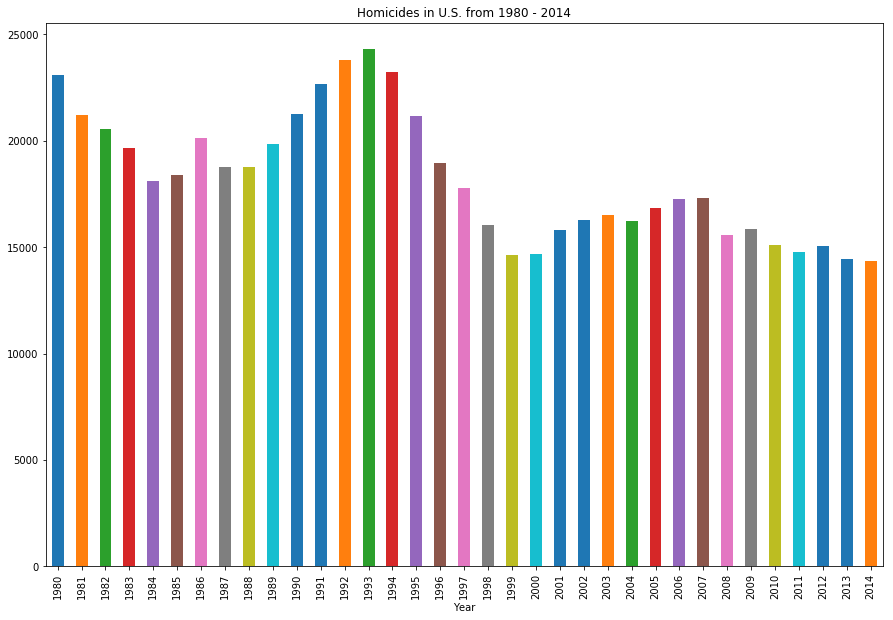

```python
# Plot of homicides v/s year
count_years['Incident'].plot(kind='bar', fontsize=10,  width=0.5,  figsize=(15, 10), title='Homicides in U.S. from 1980 - 2014')
```

The number of homicides saw a peak in 1993. After that it has drastically decreased by almost 41% from close to 24335 in 1993 to 14331 in 2014. Improvements in law enforcement and increased information and alert systems have helped decrease the number of homicides over the years.

#### 2.6.3. Statistics

Below are some of the statistics that can be deduced by the data.

```python
print("There are " + str(years2['Incident'].mean()) + " average number of homicides per year.")
```

```
There are 18241.5428571 average number of homicides per year.
```

It can be seen by the high average of 18241.5428571 homicides per year that the average over time has been high but with improvements in law enforcement, increased information and alert systems the number of homicides became 14331 in 2014 which is substantially below the average and it is continuing to decrease over time.

## 3. Linear Regression and Hypothesis testing

This part of tutorial deals with doing linear regression and prediction testing. In the process of Linear Regression, we take sample data and predict future data based on the patterns. We are going to perform 2 separate Linear Regression and compare them using F-Test for Hypothesis testing. First Linear Regression will be on Homicide cases by year and second on Homicide cases relation to Year, month and State.

### 3.1. Linear Regression on Homicide cases by year

Below we will create Linear Regression model for Number of Homicides per year and plot the Regression line with sample data. We will be utilising Linear Regression library to create and predict the model.

Link to the documentation: https://scikit-learn.org/stable/modules/generated/sklearn.linear_model.LinearRegression.html

```
On an average, Number of homicides decreases by 214.409243697 every year in the U.S.
In the U.S. Predicted Number of homicides in 2018, 2019 and 2020 will be 13738.9487395, 13524.5394958 and 13310.1302521
```

```
Text(0.5,1,'Number of Homicides per Year')
```

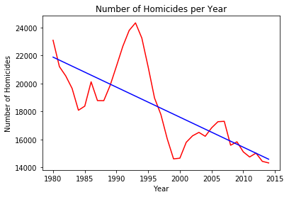

```python
# Linear Regression
yearsval = years2['Year'].values
X = [[x] for x in yearsval]
Y = [[y] for y in years2['Incident'].values]
lregfit = LinearRegression().fit(X, Y)

print("On an average, Number of homicides decreases by " + str(-1*lregfit.coef_[0][0]) + " every year in the U.S.")
print("In the U.S. Predicted Number of homicides in 2018, 2019 and 2020 will be " + str(lregfit.predict(2018)[0][0]) +", "+ str(lregfit.predict(2019)[0][0]) +" and "+ str(lregfit.predict(2020)[0][0]))

# Predicted values
pre_count = []
for x in yearsval:
    pre_count.append(lregfit.predict(x)[0][0])
years2['pre_count'] = pd.Series(pre_count, index = years2.index)

# Plotting Linear Regression
plt.plot(yearsval, years2['Incident'], color='red',)
plt.plot(yearsval, years2['pre_count'], color='blue')
plt.xlabel("Year")
plt.ylabel("Number of Homicides")
plt.title("Number of Homicides per Year")
```

### 3.2. Fitting Linear Regression models

In this part, we will fit 2 Linear Regression models. First is number of homicides with relation to year and second is number of homicides with relation to states, month and year. We will be using ols regression library found at https://www.statsmodels.org/stable/index.html.

Below is the first linear regression model

```python
# Fit first Regression model
reg1 = ols(formula='Incident ~ Year', data=years2).fit()
reg1.summary()
```

OLS Regression Results

| Dep. Variable: | Incident | R-squared: | 0.541 |
| --- | --- | --- | --- |
| Model: | OLS | Adj. R-squared: | 0.527 |
| Method: | Least Squares | F-statistic: | 38.93 |
| Date: | Sat, 15 Dec 2018 | Prob (F-statistic): | 4.78e-07 |
| Time: | 09:56:05 | Log-Likelihood: | -315.58 |
| No. Observations: | 35 | AIC: | 635.2 |
| Df Residuals: | 33 | BIC: | 638.3 |
| Df Model: | 1 |  |  |
| Covariance Type: | nonrobust |  |  |

|  | coef | std err | t | P>\|t\| | [0.025 | 0.975] |
| --- | --- | --- | --- | --- | --- | --- |
| Intercept | 4.464e+05 | 6.86e+04 | 6.505 | 0.000 | 3.07e+05 | 5.86e+05 |
| Year | -214.4092 | 34.364 | -6.239 | 0.000 | -284.324 | -144.494 |

| Omnibus: | 6.603 | Durbin-Watson: | 0.285 |
| --- | --- | --- | --- |
| Prob(Omnibus): | 0.037 | Jarque-Bera (JB): | 5.211 |
| Skew: | 0.897 | Prob(JB): | 0.0739 |
| Kurtosis: | 3.594 | Cond. No. | 3.95e+05 |

Warnings:  
[1] Standard Errors assume that the covariance matrix of the errors is correctly specified.  
[2] The condition number is large, 3.95e+05. This might indicate that there are  
strong multicollinearity or other numerical problems.

In the second Linear Regression model below, we will be using Year, Month and State. By increasing factors in formula we predict the model's accuracy will further improve.

#### Data Preparation for Second Linear Regression model

```python
data_ysr = pd.DataFrame(data, columns = ['Year', 'Month', 'State', 'Incident'])
count_ysr = data_ysr.groupby(['Year', 'Month', 'State']).count() # Count of comination
count_ysr = count_ysr[['Incident']].reset_index()
ysr = pd.DataFrame(count_ysr, columns = ['Year', 'Month', 'State', 'Incident'])
ysr.head()
```

|  | Year | Month | State | Incident |
| --- | --- | --- | --- | --- |
| 0 | 1980 | April | Alabama | 44 |
| 1 | 1980 | April | Alaska | 3 |
| 2 | 1980 | April | Arizona | 27 |
| 3 | 1980 | April | Arkansas | 21 |
| 4 | 1980 | April | California | 247 |

```python
# Fit second Regression model
reg2 = ols(formula='Incident ~ Year + Month + State + Year * Month * State', data=ysr).fit()
reg2.summary()
```

OLS Regression Results

| Dep. Variable: | Incident | R-squared: | 0.920 |
| --- | --- | --- | --- |
| Model: | OLS | Adj. R-squared: | 0.915 |
| Method: | Least Squares | F-statistic: | 173.9 |
| Date: | Sat, 15 Dec 2018 | Prob (F-statistic): | 0.00 |
| Time: | 09:56:17 | Log-Likelihood: | -78739. |
| No. Observations: | 19743 | AIC: | 1.599e+05 |
| Df Residuals: | 18519 | BIC: | 1.696e+05 |
| Df Model: | 1223 |  |  |
| Covariance Type: | nonrobust |  |  |

|  | coef | std err | t | P>\|t\| | [0.025 | 0.975] |
| --- | --- | --- | --- | --- | --- | --- |
| Intercept | 1176.7878 | 542.797 | 2.168 | 0.030 | 112.855 | 2240.720 |
| Month[T.August] | -73.0881 | 768.338 | -0.095 | 0.924 | -1579.102 | 1432.926 |
| Month[T.December] | 693.3320 | 746.222 | 0.929 | 0.353 | -769.331 | 2155.995 |
| Month[T.February] | -186.1807 | 766.434 | -0.243 | 0.808 | -1688.461 | 1316.100 |
| Month[T.January] | -159.5795 | 766.434 | -0.208 | 0.835 | -1661.860 | 1342.701 |
| Month[T.July] | -55.1993 | 768.338 | -0.072 | 0.943 | -1561.213 | 1450.815 |
| Month[T.June] | -144.0608 | 743.876 | -0.194 | 0.846 | -1602.126 | 1314.004 |
| Month[T.March] | 86.2405 | 744.932 | 0.116 | 0.908 | -1373.894 | 1546.375 |
| Month[T.May] | -210.5279 | 767.631 | -0.274 | 0.784 | -1715.156 | 1294.100 |
| Month[T.November] | -97.7174 | 730.026 | -0.134 | 0.894 | -1528.635 | 1333.201 |
| Month[T.October] | -210.6701 | 767.631 | -0.274 | 0.784 | -1715.298 | 1293.958 |
| Month[T.September] | -199.3321 | 767.631 | -0.260 | 0.795 | -1703.960 | 1305.296 |
| State[T.Alaska] | -1073.0839 | 710.136 | -1.511 | 0.131 | -2465.016 | 318.849 |
| State[T.Arizona] | -2322.6290 | 705.442 | -3.292 | 0.001 | -3705.361 | -939.897 |
| State[T.Arkansas] | -740.4621 | 705.442 | -1.050 | 0.294 | -2123.194 | 642.270 |
| State[T.California] | 5932.2819 | 705.442 | 8.409 | 0.000 | 4549.550 | 7315.014 |
| State[T.Colorado] | -810.4663 | 705.442 | -1.149 | 0.251 | -2193.198 | 572.266 |
| State[T.Connecticut] | -982.7100 | 705.442 | -1.393 | 0.164 | -2365.442 | 400.022 |
| State[T.Delaware] | -1204.5293 | 705.804 | -1.707 | 0.088 | -2587.970 | 178.912 |
| State[T.District of Columbia] | -662.4807 | 724.214 | -0.915 | 0.360 | -2082.007 | 757.045 |
| State[T.Florida] | 206.0260 | 716.760 | 0.287 | 0.774 | -1198.889 | 1610.941 |
| State[T.Georgia] | -1176.7565 | 705.442 | -1.668 | 0.095 | -2559.489 | 205.976 |
| State[T.Hawaii] | -1013.8580 | 711.813 | -1.424 | 0.154 | -2409.076 | 381.360 |
| State[T.Idaho] | -1205.8322 | 706.976 | -1.706 | 0.088 | -2591.570 | 179.906 |
| State[T.Illinois] | 1955.9598 | 705.442 | 2.773 | 0.006 | 573.228 | 3338.692 |
| State[T.Indiana] | -1461.4458 | 705.442 | -2.072 | 0.038 | -2844.178 | -78.714 |
| State[T.Iowa] | -1152.6590 | 713.825 | -1.615 | 0.106 | -2551.821 | 246.503 |
| State[T.Kansas] | -1046.5289 | 719.156 | -1.455 | 0.146 | -2456.141 | 363.083 |
| State[T.Kentucky] | -693.2883 | 712.015 | -0.974 | 0.330 | -2088.904 | 702.327 |
| State[T.Louisiana] | -1558.1119 | 705.442 | -2.209 | 0.027 | -2940.844 | -175.380 |

[output cut: 1194 more lines]

| Omnibus: | 15446.489 | Durbin-Watson: | 1.898 |
| --- | --- | --- | --- |
| Prob(Omnibus): | 0.000 | Jarque-Bera (JB): | 3453161.440 |
| Skew: | 2.846 | Prob(JB): | 0.00 |
| Kurtosis: | 67.539 | Cond. No. | 3.06e+08 |

Warnings:  
[1] Standard Errors assume that the covariance matrix of the errors is correctly specified.  
[2] The condition number is large, 3.06e+08. This might indicate that there are  
strong multicollinearity or other numerical problems.

### 3.3. Hypothesis testing

In Hypothesis testing, we consider the result we are trying to achieve as alternative hypothesis. Null hypothesis is the negative of this alternative hypothesis. So when we perform the analysis and the results disprove the null hypothesis, we reject the null hypothesis thereby proving alternative hypothesis correct. You can learn more about Null and alternative hypothesis here: https://explorable.com/null-hypothesis. Our Null Hypothesis will be that *We will not be able to improve model's accuracy when using multiple factors for relation Year, month and state as opposed to only year and there does not exist interaction between the factors of regression.*

For Hypothesis testing, we will be using F-test. F-test will help us compare which linear regression model fits better. You can learn more about F-test here: http://blog.minitab.com/blog/adventures-in-statistics-2/understanding-analysis-of-variance-anova-and-the-f-test. There is a special library in stats model called ANOVA (Analysis of Variance) for conducting F-tests on multiple regressions which we will be using here. Additional information about ANOVA can be found in its official specification here: https://www.statsmodels.org/stable/anova.html.

First Linear Regression model is a one factor ANOVA where only factor is Year whereas Second Linear Regression model is a three factor ANOVA where the three factors are Year, Month and State.

```python
# Run ANOVA on Regression 1
table = sm.stats.anova_lm(reg1, typ=2)
table
```

|  | sum_sq | df | F | PR(>F) |
| --- | --- | --- | --- | --- |
| Year | 1.641176e+08 | 1.0 | 38.928523 | 4.779064e-07 |
| Residual | 1.391237e+08 | 33.0 | NaN | NaN |

```python
# Run ANOVA on Regression 2
table = sm.stats.anova_lm(reg2, typ=2)
table
```

|  | sum_sq | df | F | PR(>F) |
| --- | --- | --- | --- | --- |
| Month | 7.773630e+04 | 11.0 | 38.885767 | 8.037512e-84 |
| State | 3.616666e+07 | 50.0 | 3980.136317 | 0.000000e+00 |
| Month:State | 2.408260e+05 | 550.0 | 2.409351 | 1.937301e-62 |
| Year | 2.987990e+05 | 1.0 | 1644.139149 | 0.000000e+00 |
| Year:Month | 5.519842e+03 | 11.0 | 2.761172 | 1.393155e-03 |
| Year:State | 1.790406e+06 | 50.0 | 197.033905 | 0.000000e+00 |
| Year:Month:State | 7.987322e+04 | 550.0 | 0.799094 | 9.997846e-01 |
| Residual | 3.365565e+06 | 18519.0 | NaN | NaN |

## 4. Conclusion

Homicides are a continuous threat to people across the world. This tutorial throws light on the pattern and trends across the U.S. Earlier such in depth analysis was impossible but with advancement of technology and specially advancements in the field of Data Science we are now able to see key trends such as average age of Perpetrators, Racial crimes and percentage of unsolved crimes we were unaware of and make informed decisions to increase safety of all citizens.

#### Key take aways:

There is a lot of information present in this dataset that we were not able to explore in this tutorial. So I will encourage you to explore it further. Some interesting ideas to explore are:

1. Relationship between Victim and Perpetrator
2. Number of homicides relation to average response time of police of the state
3. Number of homicides relation to per capita income of the state

## 5. References

1. Homicide - number of murders by U.S. state in 2017: https://www.statista.com/statistics/195331/number-of-murders-in-the-us-by-state/
2. Homicide dataset: https://www.kaggle.com/murderaccountability/homicide-reports/
3. Homicide dataset US states map: https://raw.githubusercontent.com/python-visualization/folium/master/examples/data/us-states.json
4. Folium: https://python-visualization.github.io/folium/docs-v0.6.0/
5. Matplotlib: https://matplotlib.org/
6. Pandas groupby: https://pandas.pydata.org/pandas-docs/stable/generated/pandas.DataFrame.groupby.html
7. Pandas count: https://pandas.pydata.org/pandas-docs/stable/generated/pandas.DataFrame.count.html
8. Pandas sum: https://pandas.pydata.org/pandas-docs/stable/generated/pandas.DataFrame.sum.html
9. Pandas Complete Documentation: https://pandas.pydata.org/pandas-docs/stable/
10. Linear Regression Model Using OLS: https://www.statsmodels.org/stable/index.html
11. Linear Regression Model: https://scikit-learn.org/stable/modules/generated/sklearn.linear_model.LinearRegression.html
12. F-Test: https://blog.minitab.com/blog/adventures-in-statistics-2/understanding-analysis-of-variance-anova-and-the-f-test
13. Null hypothesis: https://explorable.com/null-hypothesis
14. ANOVA Hypothesis Testing: https://www.statsmodels.org/stable/anova.html
15. US sensus dataset: https://www.kaggle.com/muonneutrino/us-census-demographic-data#acs2015_census_tract_data.csv
16. Folium implementations: https://python-visualization.github.io/folium/quickstart.html